# 🎯 Objetivos da Aula

- contextualizar a diferença entre regressão e classificação.

# 📊 O que é Regressão Logística?

Enquanto na regressão linear queremos prever um valor contínuo (ex: glicemia, pressão arterial), na classificação queremos prever uma categoria — ex: ‘diabético’ ou ‘não diabético’.” Ou seja, estamos fazendo uma classificação.

Um modelo de classificação também usa variáveis independentes (Xs) para modelar a variável dependente (Y). Porém a diferença é que o Y, que passa a ser uma classe binária: 0 ou 1.

Asso, podemos entender **regressão logística como o análogo de regressão linear para problemas de classificação.**

```python
import pandas as pd
from sklearn.datasets import load_breast_cancer

# Carregando um dataset real de saúde disponível para treinamento
data = load_breast_cancer(as_frame=True)
df = data.frame
df.head()
```

|  | mean radius | mean texture | mean perimeter | mean area | mean smoothness | mean compactness | mean concavity | mean concave points | mean symmetry | mean fractal dimension | ... | worst texture | worst perimeter | worst area | worst smoothness | worst compactness | worst concavity | worst concave points | worst symmetry | worst fractal dimension | target |
| --- | --- | --- | --- | --- | --- | --- | --- | --- | --- | --- | --- | --- | --- | --- | --- | --- | --- | --- | --- | --- | --- |
| 0 | 17.99 | 10.38 | 122.80 | 1001.0 | 0.11840 | 0.27760 | 0.3001 | 0.14710 | 0.2419 | 0.07871 | ... | 17.33 | 184.60 | 2019.0 | 0.1622 | 0.6656 | 0.7119 | 0.2654 | 0.4601 | 0.11890 | 0 |
| 1 | 20.57 | 17.77 | 132.90 | 1326.0 | 0.08474 | 0.07864 | 0.0869 | 0.07017 | 0.1812 | 0.05667 | ... | 23.41 | 158.80 | 1956.0 | 0.1238 | 0.1866 | 0.2416 | 0.1860 | 0.2750 | 0.08902 | 0 |
| 2 | 19.69 | 21.25 | 130.00 | 1203.0 | 0.10960 | 0.15990 | 0.1974 | 0.12790 | 0.2069 | 0.05999 | ... | 25.53 | 152.50 | 1709.0 | 0.1444 | 0.4245 | 0.4504 | 0.2430 | 0.3613 | 0.08758 | 0 |
| 3 | 11.42 | 20.38 | 77.58 | 386.1 | 0.14250 | 0.28390 | 0.2414 | 0.10520 | 0.2597 | 0.09744 | ... | 26.50 | 98.87 | 567.7 | 0.2098 | 0.8663 | 0.6869 | 0.2575 | 0.6638 | 0.17300 | 0 |
| 4 | 20.29 | 14.34 | 135.10 | 1297.0 | 0.10030 | 0.13280 | 0.1980 | 0.10430 | 0.1809 | 0.05883 | ... | 16.67 | 152.20 | 1575.0 | 0.1374 | 0.2050 | 0.4000 | 0.1625 | 0.2364 | 0.07678 | 0 |

5 rows × 31 columns

```python
df['target'].value_counts()
```

| target | count |
| --- | --- |
| 1 | 357 |
| 0 | 212 |

**dtype:** int64

# 📏 Conceito teórico: do valor contínuo à probabilidade

Para entender isso, imagine que somos uma equipe de vigilância epidemiológica analisando dados de uma campanha nacional de testagem. Queremos prever se uma pessoa testou positivo (1) ou negativo (0) para alguma DST a partir da idade.

- Variável explicativa (X): idade
- Variável alvo (y): teste positivo = 1, teste negativo = 0
- Suposição: pessoas mais jovens (faixa 18–30 anos) têm maior risco de exposição (comportamentos sexuais de risco, múltiplos parceiros, uso inconsistente de preservativos); já entre pessoas mais velhas, a prevalência tende a cair.

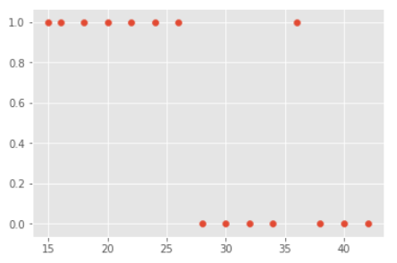

Vamos tentar modelar isso com uma regressão linear, Mas veja que ao tentar ajustar uma reta temos problemas:

- gera “probabilidades” abaixo de 0 e acima de 1;
- não representa bem a transição suave entre as classes;
- é muito sensível a outliers.

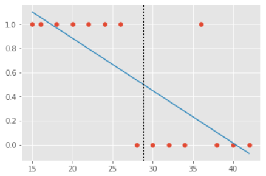

Para resolver esses problemas, em vez de utilizar regressão linear, vamos utilizar a regressão logística sempre que nos depararmos com problemas de classificação. Regressão logística nos fornecerá uma previsão sempre entre 0 e 1, de forma que possamos interpretar seus resultados como uma probabilidade válida. Além disso, regressão logística não será influenciada por outliers que não fornecem muita informação nova, pois a atenção do algoritmo será concentrada na região de fronteira.

A intuição por trás de regressão logística é bastante simples: em vez de acharmos a reta que melhor se ajusta aos dados, vamos achar uma curva em formato de 'S' que melhor se ajusta aos dados:

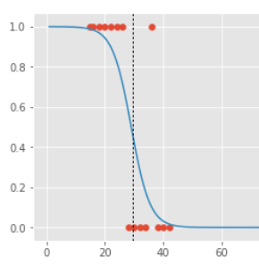

# ✔️ Função Sigmóide

Como você viu, na regressão linear, o resultado 𝑦 pode ser qualquer número real — positivo, negativo, grande, pequeno… Mas na regressão logística, queremos uma probabilidade, e probabilidade só faz sentido entre 0 e 1.

Então precisamos de uma função que: aceite qualquer número real como entrada (como o resultado linear x); mas devolva sempre um número entre 0 e 1.

A função sigmoide transforma qualquer valor real em um número entre 0 e 1. Assim, podemos interpretar a saída como uma probabilidade de pertencer à classe 1. Veja um exemplo:

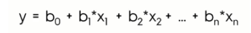

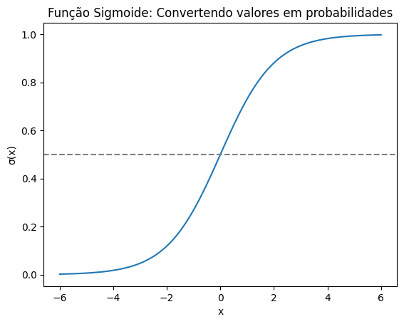

```python
import numpy as np
import matplotlib.pyplot as plt

x = np.linspace(-6, 6, 100)
y = 1 / (1 + np.exp(-x))
plt.plot(x, y)
plt.axhline(0.5, color='gray', linestyle='--')
plt.title("Função Sigmoide: Convertendo valores em probabilidades")
plt.xlabel("x")
plt.ylabel("σ(x)")
plt.show()
```

Perceba que:

- valores positivos grandes de 𝑥 → probabilidade próxima de 1
- valores negativos grandes de x → probabilidade próxima de 0
- 𝑥 = 0 → probabilidade exatamente 0,5

A função sigmoide transforma o resultado linear (que pode ser qualquer número) em algo interpretável como uma probabilidade de estar na classe 1.

Ela “achata” os valores muito altos e muito baixos, concentrando o aprendizado do modelo na região de maior incerteza — perto de 0,5, onde o modelo ainda “pensa”.

# 👉 Da regressão linear à regressão logística

Pela desmonstração da última seção, a sigmoide é o elo entre o mundo matemático da regressão e o mundo clínico das probabilidades. A saída agora é uma probabilidade de pertencer à classe positiva (1). Veja então como é diferente os algoritmos da regressão linear e da regressão logística:

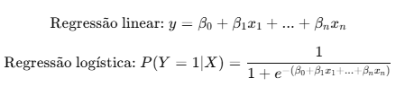

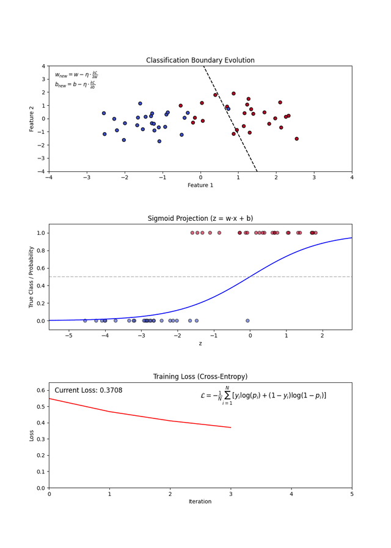